# Обучение с учителем, качество модели

```python
df_5000 = df.query('Выручка_препред < 5000')
```

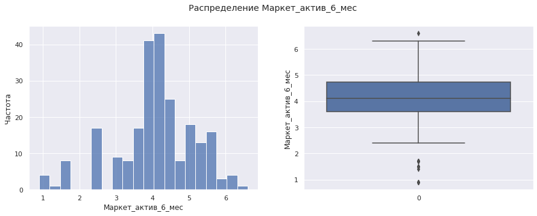

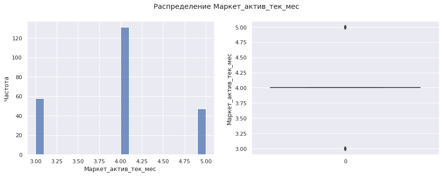

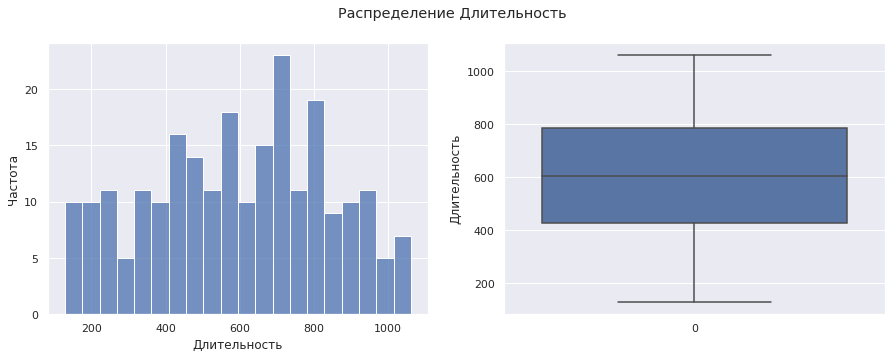

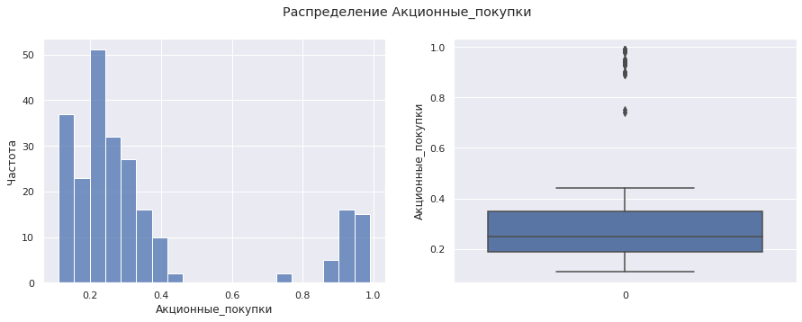

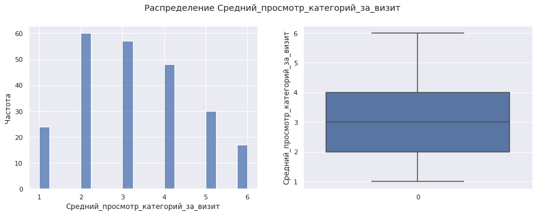

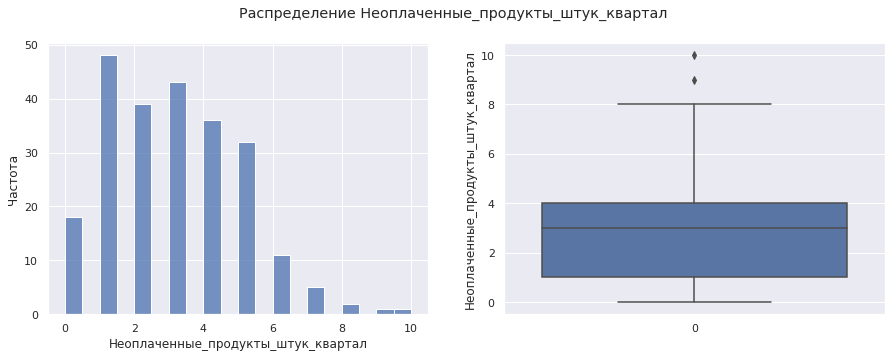

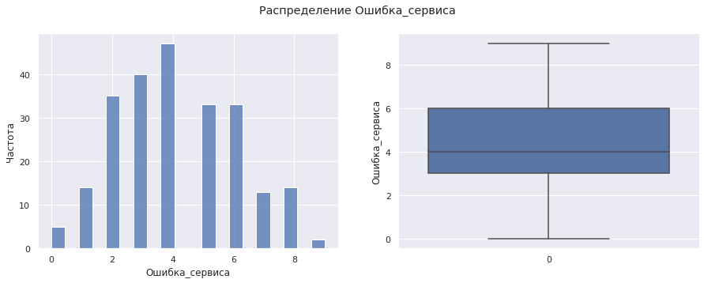

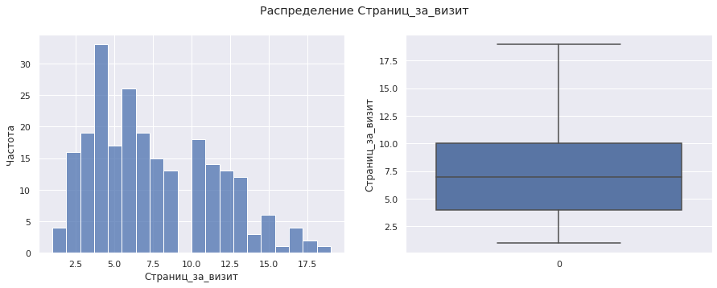

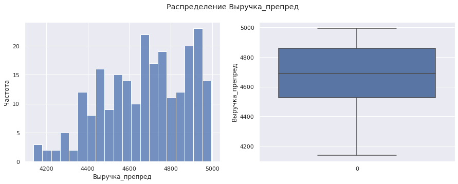

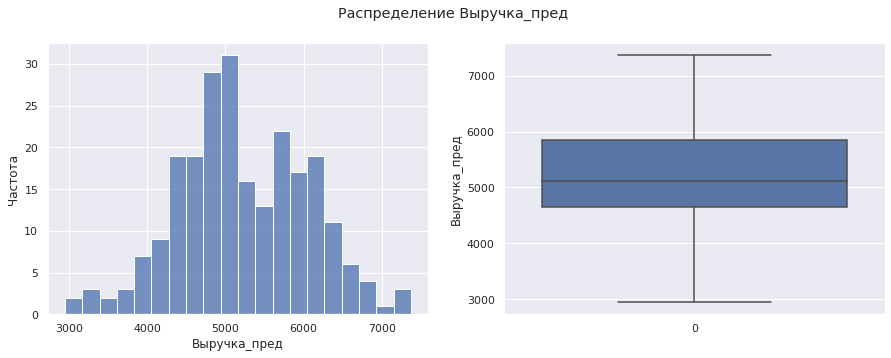

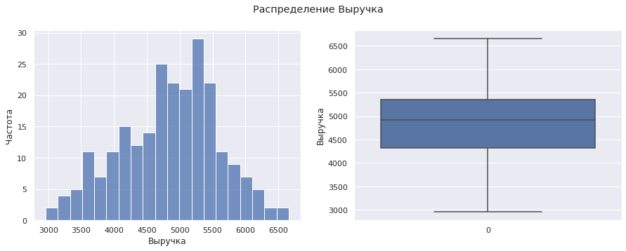

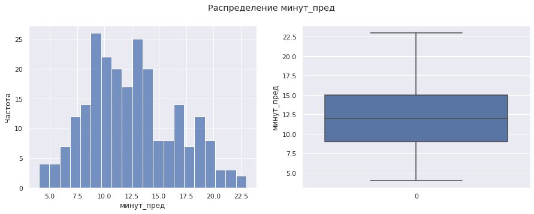

[1 more figures not shown]

```python
#построение распределений количественных признаков
for name in num_columns:
    viz_num_variable(df_5000, name)
```

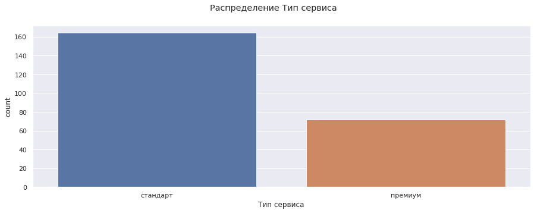

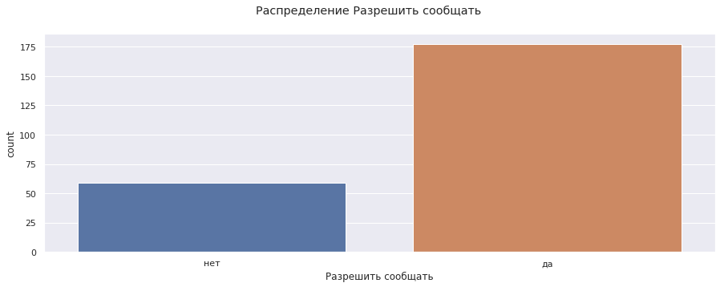

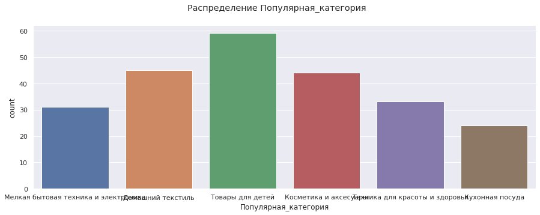

```python
#построение распределений категориальных признаков
for name in cat_columns:
    viz_cat_variable(df_5000, name)
```

Данный сегмент пользователец приобретает в основном товары для детей и домашний текстиль. Большинство таких покупателей не пользуются акциями.

Данной категории пользователей стоит попробовать разослать акции на товары для детей.

```python
market = market.merge(money, on='id', how='left')
market.head()
```

|  | id | Покупательская активность | Тип сервиса | Разрешить сообщать | Маркет_актив_6_мес | Маркет_актив_тек_мес | Длительность | Акционные_покупки | Популярная_категория | Средний_просмотр_категорий_за_визит | Неоплаченные_продукты_штук_квартал | Ошибка_сервиса | Страниц_за_визит | Выручка_препред | Выручка_пред | Выручка | минут_пред | минут_тек | Прибыль |
| --- | --- | --- | --- | --- | --- | --- | --- | --- | --- | --- | --- | --- | --- | --- | --- | --- | --- | --- | --- |
| 0 | 215349 | Снизилась | премиум | да | 4.4 | 4 | 819 | 0.75 | Товары для детей | 4 | 4 | 2 | 5 | 4472.0 | 4971.6 | 5216.0 | 10 | 12 | 4.16 |
| 1 | 215350 | Снизилась | стандарт | нет | 4.9 | 3 | 539 | 0.14 | Домашний текстиль | 5 | 2 | 1 | 5 | 4826.0 | 5058.4 | 5457.5 | 13 | 8 | 3.13 |
| 2 | 215351 | Снизилась | стандарт | да | 3.2 | 5 | 896 | 0.99 | Товары для детей | 5 | 0 | 6 | 4 | 4793.0 | 6610.4 | 6158.0 | 13 | 11 | 4.87 |
| 3 | 215352 | Снизилась | стандарт | нет | 5.1 | 3 | 1064 | 0.94 | Товары для детей | 3 | 2 | 3 | 2 | 4594.0 | 5872.5 | 5807.5 | 11 | 8 | 4.21 |
| 4 | 215353 | Снизилась | стандарт | да | 3.3 | 4 | 762 | 0.26 | Домашний текстиль | 4 | 1 | 1 | 4 | 5124.0 | 5388.5 | 4738.5 | 10 | 10 | 3.95 |

```python
def viz_market_num_variable(df, column):
    plt.figure(figsize=(15,5))
    plt.subplot(1, 2, 1)
    plt.title(f'Гистограмма {column}')
    sns.histplot(data=df, x=column, hue='Покупательская активность')
    plt.xlabel(column)
    plt.ylabel('Частота')

    plt.subplot(1, 2, 2)
    plt.title(f'Диаграмма размаха {column}')
    sns.boxplot(x='Покупательская активность', y=column, data=df);
    plt.ylabel(column)
```

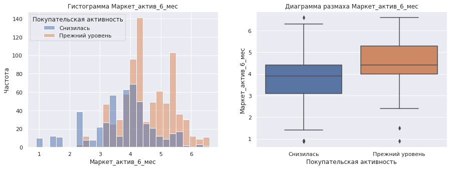

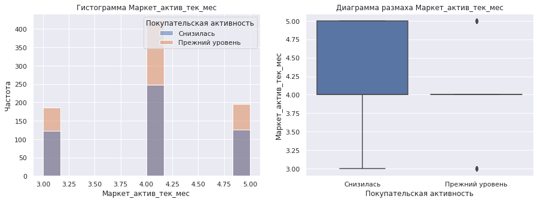

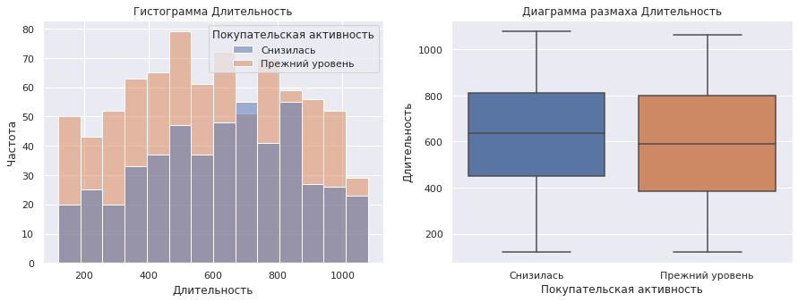

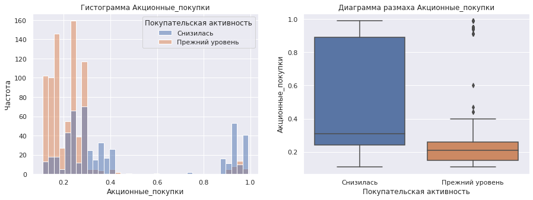

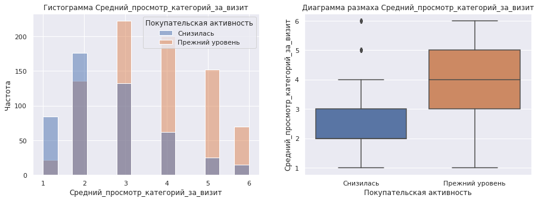

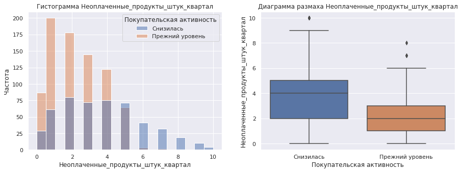

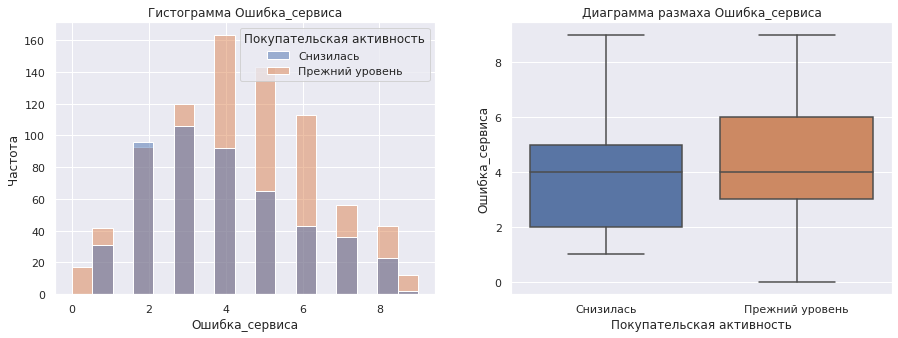

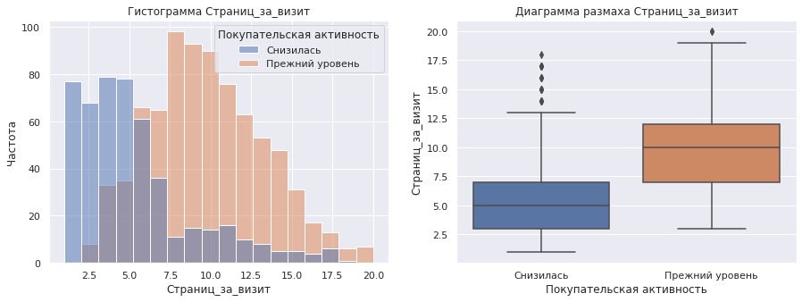

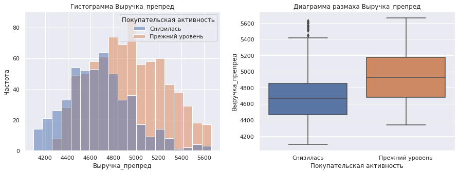

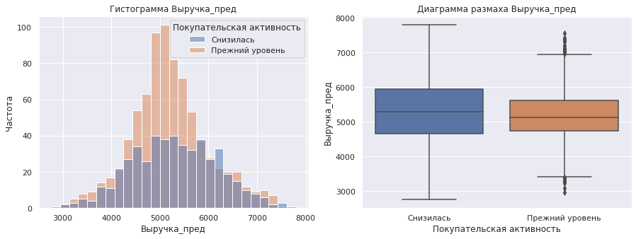

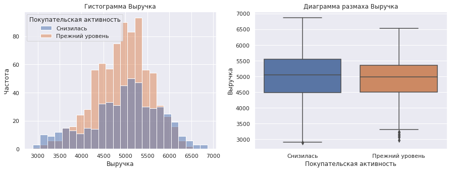

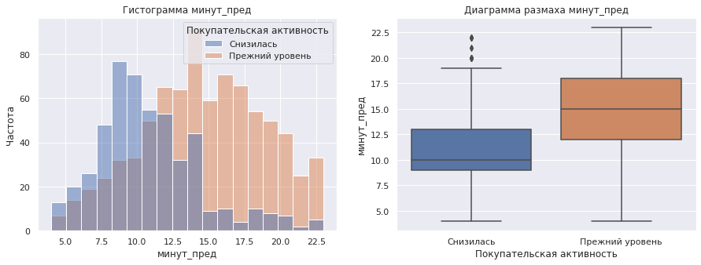

[1 more figures not shown]

```python
for column in num_columns:
    viz_market_num_variable(market, column)
```

Выделим пользователец по категории товаров.

```python
market_kids = market.query('Популярная_категория == "Товары для детей"')
market_kids.head()
```

|  | id | Покупательская активность | Тип сервиса | Разрешить сообщать | Маркет_актив_6_мес | Маркет_актив_тек_мес | Длительность | Акционные_покупки | Популярная_категория | Средний_просмотр_категорий_за_визит | Неоплаченные_продукты_штук_квартал | Ошибка_сервиса | Страниц_за_визит | Выручка_препред | Выручка_пред | Выручка | минут_пред | минут_тек | Прибыль |
| --- | --- | --- | --- | --- | --- | --- | --- | --- | --- | --- | --- | --- | --- | --- | --- | --- | --- | --- | --- |
| 0 | 215349 | Снизилась | премиум | да | 4.4 | 4 | 819 | 0.75 | Товары для детей | 4 | 4 | 2 | 5 | 4472.0 | 4971.6 | 5216.0 | 10 | 12 | 4.16 |
| 2 | 215351 | Снизилась | стандарт | да | 3.2 | 5 | 896 | 0.99 | Товары для детей | 5 | 0 | 6 | 4 | 4793.0 | 6610.4 | 6158.0 | 13 | 11 | 4.87 |
| 3 | 215352 | Снизилась | стандарт | нет | 5.1 | 3 | 1064 | 0.94 | Товары для детей | 3 | 2 | 3 | 2 | 4594.0 | 5872.5 | 5807.5 | 11 | 8 | 4.21 |
| 6 | 215355 | Снизилась | стандарт | нет | 4.7 | 4 | 284 | 0.17 | Товары для детей | 5 | 1 | 6 | 4 | 4749.0 | 3772.6 | 3263.0 | 10 | 12 | 5.26 |
| 12 | 215363 | Снизилась | стандарт | нет | 4.9 | 4 | 923 | 0.29 | Товары для детей | 6 | 0 | 3 | 1 | 4633.0 | 6128.3 | 6010.0 | 5 | 8 | 1.83 |

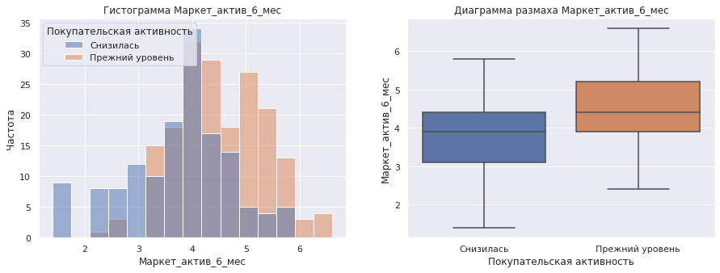

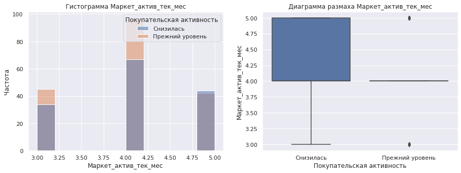

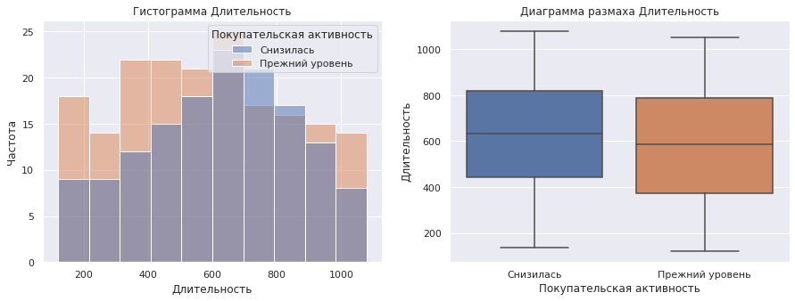

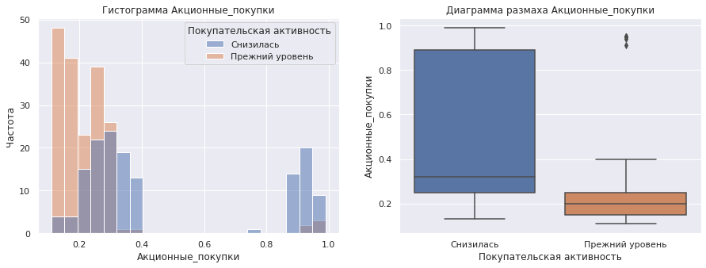

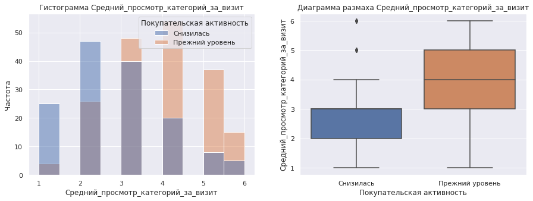

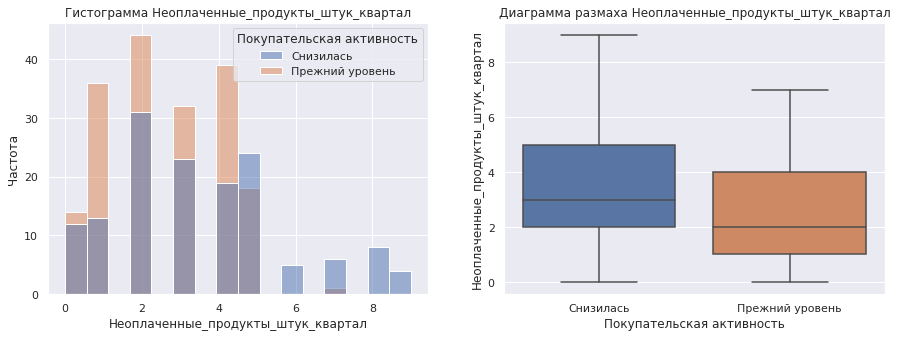

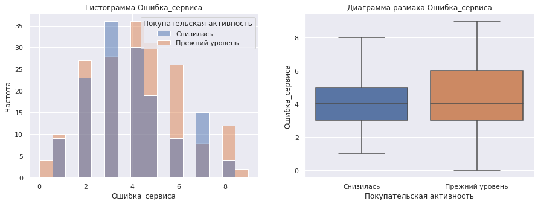

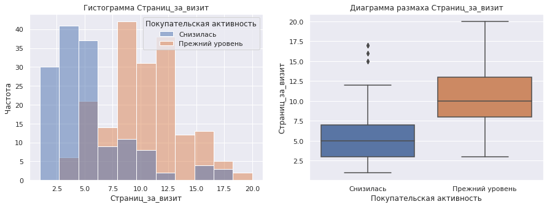

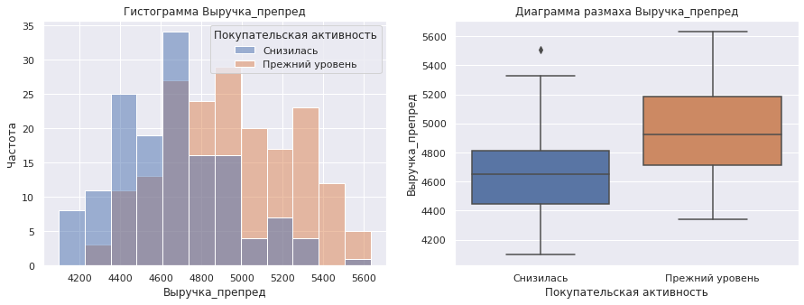

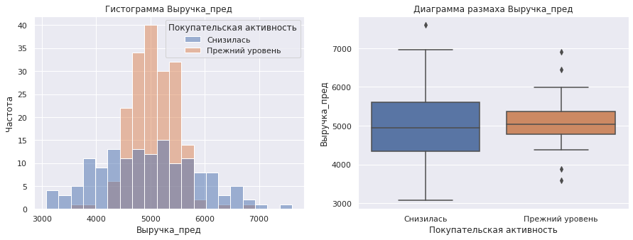

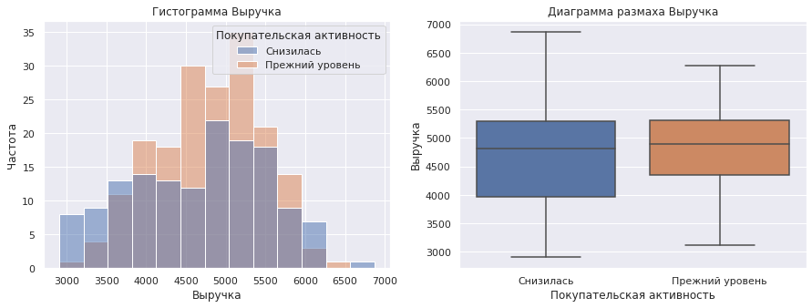

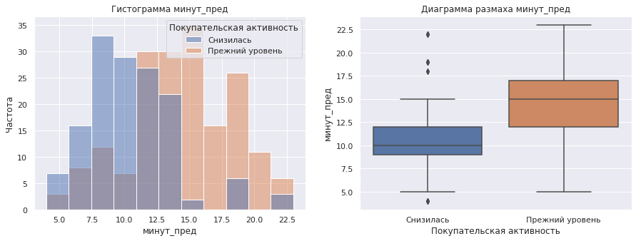

[1 more figures not shown]

```python
for column in num_columns:
    viz_market_num_variable(market_kids, column)
```

2 месяца назад покупатели со сниженной активностью давали меньше выручки, чем с покупателей с прежним уровнем покупательской активности. В предыдущим и этом месяце у них выручка приблизительно на одинаковом уровне.

Можно попробовать провести акции на деские товары и разместить их на легко заметных местах сайта.

## Общий вывод

В ходе проекта были проанализированы данные о покупателях интернет-магазина "В один клик" с целью прогнозирования покупательской активности в следующие 3 месяца.

Был проведен поиск лучшей модели МО. Это SVC - "Метод опорных векторов" со значением метрики roc_auc=0.91.

У выбранной модели была проанализирована важность признаков: Длительность, минут_тек, Средний_просмотр_категорий_за_визит, минут_пред, Страниц_за_визит

Можно выделить сегмент покупателей, которые покупают во основном акционные товары (со значениями признака "Акционные_покупки" более 0.6).

Выделен сегмент пользователей, приобретающих в основном товары для детей и домашний текстиль. Большинство таких покупателей не пользуются акциями. Данной категории пользователей стоит попробовать разослать акции на товары для детей.

**Ход работ:**

1. В ходе работы были загружены и изучены 4 таблицы с данными о сайте.
2. Выполнена предобработка данных
   - Обработаны дубликаты
   - Исправлены ошибки в названиях столбцов
3. Проведен исследовательский анализ данных

     market_money
   - "Выручка" распределен нормально, аномальноем значение удалено;

     market_time
   - "Минуты" распределен нормально;

     money
   - "Прибыль" распределен нормально;

     Выбраны пользователи, которые были активны в последние месяца
4. Объединены даные таблиц;
5. Исследована корреляция данных. От мультиколлениарности удалось избавиться;
6. Был проведен поиск лучшей модели МО. Это SVC - "Метод опорных векторов" со значением метрики roc_auc=0.91;
7. Определены важные признаки: Длительность, минут_тек, Средний_просмотр_категорий_за_визит, минут_пред, Страниц_за_визит;
8. Пользователи разделены на сегменты. Выделены пользователи, покупающие в основном детские товары и покупающие только по акции